# Comparing cancer stem cell (CSC) content among cytotoxic drugs across a range of spheroid viability index.

[Krittiyabhorn Kongtanawanich](https://github.com/KuchikiNamthip)

2024-06-15

# Overview of R analysis for comparing cancer stem cell (CSC) content among cytotoxic drugs across a range of spheroid viability index (SVI).

To compare CSC content under chemotherapies, we developed a method for comparing CSC index within a range of spheroid viability index (SVI) by calculating the normalized CSC index’s area under the curve (AUC). Briefly, a range of SVI is defined based on the SVI of all drugs. The CSC index of each SVI value is fit by cubic polynomial spline, and then calculate AUC of the CSC index by integration. To compare CSC content across a range of SVI, an AUC of the CSC index is calculated for each drug. The CSC index’s AUC is further normalized by the vehicle control. Statistical test is performed, and bar graphs are used for data visualization.

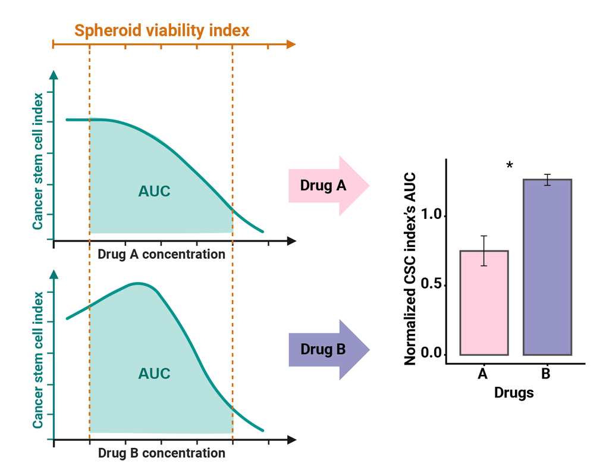

Figure 1: Overview of analysis for CSC content among cytotoxic drugs across a range of SVI. (Created by BioRender.com / Mahidol University)

## 1. Analysis overview

#### Here, the analysis is composed of 5 main parts below.

1. Section 1: Define information of the Dataset.
2. Section 2: Load input data.
3. Section 3: Create an analysis pipeline.
   - Part 3.1: Find SVI range for all drugs.  
     3.1.1 Find theminimum SVI of each drug.  
     3.1.2 Define maximum and minimum of SVI for all drugs.  
     3.1.3 Define the range of SVI to calculate AUC of the CSC index.
   - Part 3.2: Find the AUC of CSC index according to the selected SVI range.  
     3.2.1 Define function to calculate the AUC of CSC index.  
     3.2.2 Calculate the AUC of CSC index for vehicle control.  
     3.2.3 Calculate normalized CSC index’s AUC of each drug.
   - Part 3.3: Create summary analysis.
4. Section 4: Statistical test
   - Part 4.1: Normality test
   - Part 4.2: Statistical test
5. Section 5: Data visualization

## 2. Inputs

The CSC index of each drug was created from the file name `DrugX_Input_forCSCindexAUC.csv` from [3D multi-spheroid model for cytotoxicity evaluation of anticancer drugs](https://kuchikinamthip.github.io/3D_CSCimaging/2_3D-CytotoxicityEvaluation/script/2_3D-CytotoxicityEvaluation.html) which will be used as input data for this analysis.

To compare the CSC index of cytotoxic drugs across a range of spheroid viability index (SVI), we used drug A and drug B as examples.

Here, we provided [a set of example inputs](https://github.com/KuchikiNamthip/3D_CSCimaging/tree/f3319a92696270925fab4f4dc1cad20d03508e49/3_CompareCSCcontent_amongDrugs/data) which contained `A_Input_forCSCindexAUC.csv`and `B_Input_forCSCindexAUC.csv` for drug A and drug B, respectively.

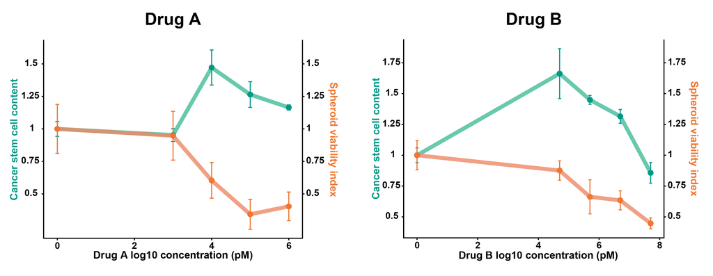

Figure 2: Double y-axis graphs show spheroid viability index (SVI) and CSC index of drug A (left) and drug B(right).

## Analysis for Comparing cancer stem cell (CSC) content among cytotoxic drugs across a range of spheroid viability index.

### Import R library

```r
library(dplyr)
library(ggplot2)
library(splines) # For cubic spline fitting curve
library(ggpubr) # For statistical test
library(viridis) # For color library
```

## Section 1: Define information of the dataset.

To define information of the dataset.

1.1 Define working directory: `Output_Directory`  
1.2 Define input directory: `Input_Directory`

```r
# Dataset example: drug A and drug B
  ## Output directory
    Output_Directory  <- 'path/to/directory'
    setwd(Output_Directory)

  ## Input directory
    Input_Directory   <- 'path/to/directory'
```

## Section 2: Load the input data.

```r
    FileNames <- list.files(Input_Directory)  # Get a list of .csv files in the input directory
    FileNames <- as.list(FileNames) # Make .csv files as a list
```

Import two `.csv` files for 2 drugs and then calculate the required variable for further analysis.

```r
# Create a blank list to store `Experimental_drug` information.
  Experimental_list <- list()

# Calculate the required variable for all drugs for further analysis.
for (Drug_FileName in FileNames){
    # Import each `.csv` file.
      Drug_FilePath       <- file.path(Input_Directory, Drug_FileName)
      Experimental_DrugX  <- read.csv(Drug_FilePath)

      ## Change all columns to numeric except the`Drug` column.
        Experimental_DrugX[, -1] <- apply(Experimental_DrugX[, -1],
                                          2,
                                          as.numeric
                                          )
        Experimental_DrugX

    # Rename the data frame to show the drug name.
      ## Extract the drug name.
        Drug_Name <- sub("_.*", "", Drug_FileName)

      ## Rename the data frame.
        Experimental_Data <- assign(paste0("Experimental_Drug", Drug_Name),
                                      Experimental_DrugX
                                    )

    # Store the data frame into the list `Experimental_list`.
      Experimental_list[[length(Experimental_list)+1]] <- Experimental_Data
  }
```

Observe the `Experimental_Drug` data

```r
# The list which shows information of all drugs.
head(Experimental_list)
```

```
## [[1]]
##    Drug Concentration_pM log10_Concentration_pM       SVI  CSCindex Replicate
## 1     A            1e+06                      6 0.5266515 1.1670821         1
## 2     A            1e+06                      6 0.3727367 1.1439455         2
## 3     A            1e+06                      6 0.3128734 1.1833153         3
## 4     A            1e+05                      5 0.4753377 1.2614324         1
## 5     A            1e+05                      5 0.2924306 1.3646002         2
## 6     A            1e+05                      5 0.2619729 1.1668776         3
## 7     A            1e+04                      4 0.7616551 1.6280216         1
## 8     A            1e+04                      4 0.5151447 1.3951609         2
## 9     A            1e+04                      4 0.5343289 1.3931141         3
## 10    A            1e+03                      3 1.0047226 0.9452869         1
## 11    A            1e+03                      3 1.0996911 1.0053784         2
## 12    A            1e+03                      3 0.7377690 0.9074044         3
## 13    A            0e+00                      0 0.8029457 0.9476974         1
```

[output cut: 20 more lines]

```r
# Drug A
head(Experimental_DrugA)
```

```
##   Drug Concentration_pM log10_Concentration_pM       SVI CSCindex Replicate
## 1    A            1e+06                      6 0.5266515 1.167082         1
## 2    A            1e+06                      6 0.3727367 1.143946         2
## 3    A            1e+06                      6 0.3128734 1.183315         3
## 4    A            1e+05                      5 0.4753377 1.261432         1
## 5    A            1e+05                      5 0.2924306 1.364600         2
## 6    A            1e+05                      5 0.2619729 1.166878         3
```

```r
# Drug B
head(Experimental_DrugB)
```

```
##   Drug Concentration_pM log10_Concentration_pM       SVI  CSCindex Replicate
## 1    B            5e+07                    7.7 0.4828559 0.9296289         1
## 2    B            5e+07                    7.7 0.4610764 0.8759742         2
## 3    B            5e+07                    7.7 0.3978878 0.7660433         3
## 4    B            5e+06                    6.7 0.6813254 1.3671360         1
## 5    B            5e+06                    6.7 0.6765575 1.3230907         2
## 6    B            5e+06                    6.7 0.5448808 1.2561047         3
```

## Section 3: Create an analysis pipeline.

### Part 3.1: Find SVI range for all drugs.

#### 3.1.1 Find the minimum SVI of each drug.

```r
# Create a blank data frame to store `DrugX_minSVI` from the highest concentration of each drug.
Data_minSVI <- data.frame()

# Create a for loop to calculate the lowest SVI from the highest concentration of each drug.
for (Experimental_DrugX in Experimental_list){

  # Find the highest concentration of the drug.
    DrugX_MaxConc <- max(Experimental_DrugX$Concentration_pM)

  # Filter only SVI of the highest drug concentration.
    DrugX_minSVI <- Experimental_DrugX %>%
                      dplyr::filter(Concentration_pM == DrugX_MaxConc) %>%
                      select(Drug, SVI)

    Data_minSVI <- rbind(Data_minSVI,
                          DrugX_minSVI
                         )
  }

# Show the SVIs from the highest concentration of each drug.
head(Data_minSVI)
```

```
##   Drug       SVI
## 1    A 0.5266515
## 2    A 0.3727367
## 3    A 0.3128734
## 4    B 0.4828559
## 5    B 0.4610764
## 6    B 0.3978878
```

#### 3.1.2 Define maximum and minimum of SVI for all drugs.

```r
# Define maximum of SVI.
  HighestSVI_LastPoint <- 1

  print(paste0("The last point (highest SVI) of the AUC range across all drugs is ", HighestSVI_LastPoint))
```

```
## [1] "The last point (highest SVI) of the AUC range across all drugs is 1"
```

Minimum SVI will be determined by the highest value among the minimum SVIs across all drugs, to further analyze the CSC index within the same range of SVI.”

```r
# Find the lowest of SVI across all drugs.
  minSVI <- max(Data_minSVI$SVI)
  print(paste0("Minimum SVI of across all drugs is ", minSVI))
```

```
## [1] "Minimum SVI of across all drugs is 0.526651533159554"
```

```r
  Rounded_minSVI <- round(minSVI, digits = 2)
  LowestSVI_1stPoint <- ceiling(Rounded_minSVI / 0.05) * 0.05

  print(paste0("The 1st point (lowest SVI) of the AUC range across all drugs is ", LowestSVI_1stPoint))
```

```
## [1] "The 1st point (lowest SVI) of the AUC range across all drugs is 0.55"
```

#### 3.1.3 Define the range of SVI to calculate AUC of the CSC index.

```r
# Summarize the range of SVI.
  SVI_Range <- c(HighestSVI_LastPoint,
                  LowestSVI_1stPoint
                 )
  print(paste("The SVI range for calculating the AUC of the CSC index is between", HighestSVI_LastPoint, "and", LowestSVI_1stPoint))
```

```
## [1] "The SVI range for calculating the AUC of the CSC index is between 1 and 0.55"
```

### Part 3.2: Find the AUC of CSC index according to the selected SVI range.

#### 3.2.1 Define function to calculate the AUC of CSC index.

```r
AUC.CSCindex.finding <- function(Experimental_DrugX, SVI_Range){

  # Define parameters
  y <- Experimental_DrugX$CSCindex
  x <- Experimental_DrugX$SVI

  # Fit a cubic spline
  fit <- lm(y ~ bs(x, degree = 3))

  # Define the function to integrate
  spline_function <- function(x_new) {
    predict(fit, newdata = data.frame(x = x_new))
  }

  # Set the range by SVI
  MinSVI <- min(SVI_Range)
  MaxSVI <- max(SVI_Range)

  # Calculate the AUC off CSC index using numerical integration
  area <- integrate(spline_function, lower = MinSVI, upper = MaxSVI)
  AUC_CSCindex <- area$value
  return(AUC_CSCindex)

}
```

#### 3.2.2 Calculate the AUC of CSC index for vehicle control.

```r
  # Define information.
    VehicleControl_df <- data.frame(Drug = "Control",
                                      SVI = SVI_Range,
                                      CSCindex = 1
                                    )

  # Calculate the AUC of CSC index for vehicle control.
    AUC_Control <- AUC.CSCindex.finding(VehicleControl_df, SVI_Range)

  # Observe the `AUC_Control` data.
    AUC_Control
```

```
## [1] 0.45
```

#### 3.2.3 Calculate normalized CSC index’s AUC of each drug.

```r
# Create a blank data frame to store the normalized AUC of CSC index (`AUC_N`) form all replicates of each drug.
NormalizedAUC_CSCindex <- data.frame()

  for (Experimental_DrugX in Experimental_list){

    # Extract information of each replicate.
    Rep1_Experimental_DrugX <- filter(Experimental_DrugX, Replicate == 1)
    Rep2_Experimental_DrugX <- filter(Experimental_DrugX, Replicate == 2)
    Rep3_Experimental_DrugX <- filter(Experimental_DrugX, Replicate == 3)

    # Make a list contains all replicate from the same drug.
    Replicate_list <- list(Rep1_Experimental_DrugX,
                           Rep2_Experimental_DrugX,
                           Rep3_Experimental_DrugX)

    # Calculate normalized AUC of CSC index for each replicate.
      for (ReplicateN in Replicate_list){

        # Calculate AUC of CSC index for each replicate.
          AUCvalue <- AUC.CSCindex.finding(ReplicateN, SVI_Range)

        # Calculate normalized AUC of CSC index for each replicate.
          NormalizedAUC <- AUCvalue/AUC_Control

        # Store the normalized AUC of CSC index into `NormalizedAUC_CSCindex` data frame.
        AUC_N <- c(ReplicateN$Drug[1], AUCvalue,
                    AUC_Control, NormalizedAUC, ReplicateN$Replicate[1])

        NormalizedAUC_CSCindex <- rbind(NormalizedAUC_CSCindex, AUC_N)
      }
  }

# Rename the columns
  colnames(NormalizedAUC_CSCindex) <- c("Drug", "AUC.CSCindex_Drug", "AUC.CSCindex_Control", "NormalizedAUC.CSCindex", "Replicate")

## Change all columns to numeric except the`Drug` column.
  NormalizedAUC_CSCindex[, -1] <- apply(NormalizedAUC_CSCindex[, -1],
                                    2,
                                    as.numeric
                                    )
```

Observe the `NormalizedAUC_CSCindex` data.

```r
# The data frame shows information of all drugs.
NormalizedAUC_CSCindex
```

```
##   Drug AUC.CSCindex_Drug AUC.CSCindex_Control NormalizedAUC.CSCindex Replicate
## 1    A         0.5556640                 0.45              1.2348089         1
## 2    A         0.5381571                 0.45              1.1959046         2
## 3    A         0.4297619                 0.45              0.9550265         3
## 4    B         0.6907119                 0.45              1.5349153         1
## 5    B         0.6834085                 0.45              1.5186856         2
## 6    B         0.4860844                 0.45              1.0801876         3
```

### Part 3.3: Create summary analysis.

```r
# Write the `NormalizedAUC_CSCindex`  into a `.csv` file.
  write.csv(NormalizedAUC_CSCindex,
              paste0("RawResult", "_NormalizedAUC.CSCindex_AllDrugs.csv"), row.names = FALSE)

# Summarize the analysis.
  Summary_NormalizedAUC <- NormalizedAUC_CSCindex %>%
                                      group_by(Drug) %>%
                                      summarise_at(vars(NormalizedAUC.CSCindex),
                                                   list(Mean_Normalized_AUC = mean,
                                                        SD_Normalized_AUC   = sd)
                                                   )
  # Write the `Summary_NormalizedAUC`  into a `.csv` file.
    write.csv(Summary_NormalizedAUC, "Summary_NormalizedAUC.CSCindex.csv", row.names = FALSE)
```

Observe the `Summary_NormalizedCSCindexAUC` data.

```r
Summary_NormalizedAUC
```

```
## # A tibble: 2 × 3
##   Drug  Mean_Normalized_AUC SD_Normalized_AUC
##   <chr>               <dbl>             <dbl>
## 1 A                    1.13             0.152
## 2 B                    1.38             0.258
```

## Section 4: Statistical test

### 4.1 Normality test

To determine whether the data follows a normal distribution, the normality test should be performed.

```r
  shapiro.test(NormalizedAUC_CSCindex$NormalizedAUC.CSCindex)
```

```
##
##  Shapiro-Wilk normality test
##
## data:  NormalizedAUC_CSCindex$NormalizedAUC.CSCindex
## W = 0.91579, p-value = 0.4756
```

For the example dataset, the result showed that the data is normally distributed.

### 4.2 Statistical test

According to the normal distribution of the data, a t-test was used for statistical testing.

If your data does not follow a normal distribution, a non-parametric test like the “Wilcoxon rank-sum test” should be used instead.  
Here, we also provide the choice of statistical tests as shown below.

```r
# Wilcoxon rank-sum test
  Stat_NormalizedAUC_Wilcox <- compare_means(NormalizedAUC.CSCindex ~ Drug,
                                        data = NormalizedAUC_CSCindex,
                                        method = "wilcox.test"
                                      )

# T-test
  Stat_NormalizedAUC_Ttest <- compare_means(NormalizedAUC.CSCindex ~ Drug,
                                        data = NormalizedAUC_CSCindex,
                                        method = "t.test"
                                      )

  # Write the `Stat_NormalizedAUC_Ttest`  into a `.csv` file.
    write.csv(Stat_NormalizedAUC_Ttest,
                paste0("Stat", "_NormalizedAUC.CSCindex.csv"), row.names = FALSE)
```

Observe the `Stat_NormalizedAUC_Ttest` data.

```r
Stat_NormalizedAUC_Ttest
```

```
## # A tibble: 1 × 8
##   .y.                    group1 group2     p p.adj p.format p.signif method
##   <chr>                  <chr>  <chr>  <dbl> <dbl> <chr>    <chr>    <chr>
## 1 NormalizedAUC.CSCindex A      B      0.238  0.24 0.24     ns       T-test
```

## Section 5: Data visualization

Data visualization is presented as a bar graph in an object named `NormalizedAUC_plot` and saved as a `.png` file.

```
## [1] "The .png file was saved as 'NormalizedAUC_plot.png'"
```

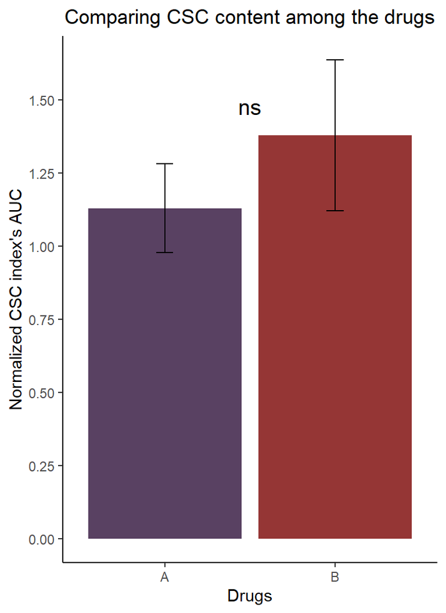

```r
NormalizedAUC_plot <- ggplot(Summary_NormalizedAUC, aes(x = Drug)) +
                        geom_bar(aes(y = Mean_Normalized_AUC, fill = Drug),
                                 stat = "identity", alpha = 0.8) +

                        geom_errorbar(aes(ymin = Mean_Normalized_AUC - SD_Normalized_AUC,
                                          ymax = Mean_Normalized_AUC + SD_Normalized_AUC),
                                          width = 0.1, position = position_dodge(0.9)) +

                        scale_fill_viridis(discrete = TRUE, option = "H")  +

                        scale_y_continuous(breaks = seq(0, (max(Summary_NormalizedAUC$Mean_Normalized_AUC)+0.25),
                                                        by = 0.25)) +

                        labs(title = "Comparing CSC content among the drugs",
                                 x = "Drugs",
                                 y = "Normalized CSC index's AUC") +

                        theme_classic() +
                        theme(plot.title = element_text(hjust = 0.5)) +
                        theme(legend.position = "none")

# Manually annotate the statistical significance
  NormalizedAUC_plot_wtStat <- NormalizedAUC_plot +
                                  annotate("text",
                                            x = 1.5,
                                            y = 0.1 + max(Summary_NormalizedAUC$Mean_Normalized_AUC),
                                            label = "ns",
                                            size = 5)

# Save the plot as a `.png` file.
  ggsave('NormalizedAUC_plot.png',
         width = 4, height = 4,
         dpi = 300, units = 'in')
  print(paste0("The .png file was saved as '", "NormalizedAUC_plot.png'"))
```

Figure 3: Comparing CSC content among cytotoxic drugs across a range of 3D multi-spheroid’s dose-response.